# Traffic Flow Prediction

#### (Final Project Blog - Intro to Data Science Course)

Since the time when first car was invented, the car production is rapidly increasing. All over the world number of cars is growing faster than new roads construction (especially in developing world). This means the traffic flow is not optimal everywhere at all time. This problem can be explained if we consider traffic as demand and supply problem. Demand is obtained from number of vehicles at particular time and particular place, where supply is considered as road capacities, speed limitations and other traffic characteristics. If the demand outgrows supply, traffic congestion is the result. This complex nonlinear correlation between demand and supply can be modelled and this has been a focus of research for many researchers in the next few decades.

In this blog, prediction of traffic flow 5 hours in to the future is presented, using linear regression model. The prediction is done, by using several traffic parameters (flow, gap, speed...) measured from traffic loop sensors, in combination with date-time related features (day of the week, hour of day...). Results shows that the method is applicable for this particular problem, due to the fact that the R2 measure (coefficient of determination) of our best developed model is greater than 0.7. Finally, since this work described only modelling of one particular sensor, we also address how this approach could be further improved by using MapReduce techniques, which would enable us to model thousands of different sensors that we could use for traffic predictions.

[figure not shown]

## Introduction

Traffic congestions can have substantial effects on quality of life, especially in bigger cities. It is estimated that traffic congestions in United States waste 2 billion gallons of fuel per year. 135 million US drivers spend 2 billion hours trapped per year. Altogether, 100 billion USD are spent because of fuel in US only. For an average American driver, this means 800 USD per year. Beside economical part of view (saving money and time), there is also ecological one. The pollution could be reduced significantly by reducing the traveling time and thus reducing the emission.

The above mentioned astonishing facts, are the main reasons why governments are investing in Intelligent Transportation Systems (for short, ITS) technologies that would lead to more efficient use of transportation network. The traffic prediction models have become a main component of most Intelligent Transportation Systems (ITS). Accurate real time information and traffic flow prediction of parameters (such as traffic volume, occupancy, travel time…) is a crucial component for almost every ITS.

ITS very in technologies applied; from advanced travel information systems (ATIS), variable message signs (VMS), traffic signal control systems, to special user friendly applications such as travel advisors. The aim of them all is the same, to ease traffic flow, reduce traffic congestions and decrease travel time with advising drivers about their routes, time of departure, or even type of transportation.

## Data

For this research we used the traffic loop sensor measurement data for Slovenia. There are 447 loop sensors installed inside the Slovenian roads (see figure). Every sensor data contains meta data information (such as location of the sensor, direction, region), as well as some regular traffic status measurements (such as flow, gap, occupancy, speed, traffic status). Real-time data stream is refreshed every 5 minutes and is accessible via web API in JSON format at http://opendata.si/promet/counters/. This service has been continuously crawled for the last 6 months by which we have created a historical dump of traffic related data, with 5 minutes resampling interval, for all 447 sensors. The availability of large amount of data makes this problem highly suitable for several machine learning methods.

[figure not shown]

### Exploratory Data Analysis

From the previously mentioned database, we have created a dump file (in csv format) of one specific traffic loop sensor (*SensorID: 0178_11*). This sensor is placed on one of the busiest roads, located on the bypass of the Slovenias capital city Ljubljana. This 6 months long historical data dump will be used for further analysis. Our main goal is to design a prediction model (for this specific sensor) that will be able to predict traffic, 5 hour into the future.

```python
%matplotlib inline
import pandas as pd
import numpy as np
import matplotlib.pyplot as plt
from scipy import stats, linalg
pd.options.mode.chained_assignment = None
```

```python
# Import data from csv
traffic_file_path = "Data/0178_11.csv"
traffic_data = pd.read_csv(traffic_file_path)
traffic_data = pd.read_csv(traffic_file_path, header=None,
                               names=["SensorID","DateTime","Flow","Gap","Occupancy","Speed","TrafficStatus"],
                               index_col='DateTime', parse_dates=True, dayfirst=True)

traffic_data.head()
#traffic_data[15:25]
```

| DateTime | SensorID | Flow | Gap | Occupancy | Speed | TrafficStatus |
| --- | --- | --- | --- | --- | --- | --- |
| 2014-01-01 01:00:00 | 0178-11 | 192 | 18.5 | 14 | 105 | 1 |
| 2014-01-01 01:05:00 | 0178-11 | 156 | 21.6 | 11 | 100 | 1 |
| 2014-01-01 01:10:00 | 0178-11 | 228 | 16.3 | 16 | 112 | 1 |
| 2014-01-01 01:15:00 | 0178-11 | 300 | 11.7 | 23 | 99 | 1 |
| 2014-01-01 01:20:00 | 0178-11 | 144 | 22.2 | 10 | 108 | 1 |

From the imported dataframe, we can see that we have a historical record with timestamps, that contains 5 different sensor measurements:

- **flow:** is the number of vehicles passing a reference point, per hour.
- **gap:** average time gap (in seconds) between vehicles, per hour.
- **occupancy:** occupancy of the road in the 1/10th of the percent. For example, value 57 from data converts to 5.7%.
- **speed:** average speed (*km/h*) of vehicles, per hour. Speed of every vehicle is almost impossible to track and is therefore estimated from other parameters.
- **traffic status:** Numeric status of the traffic. 1 being *"normal traffic"*, and 5 being *"heavy traffic with congestions"*.

At a bottom figure, we can see a visualisation of data for one randomly selected week from our data. What we can instantly see from the Flow graph (upper left) are the distinguished daily patterns over the week. This can be seen because, every day during the night, traffic flow is very low and during the day number of cars increases. We can observe how this daily patterns during the week are very similar, where patterens for weekend are different. What can also be observed is the distinguished peak in the morning (morning rush hour), followed by another peak (afternoon rush hour).

Similar findings can be seen from the "Occupancy" graph (bottom left) and "Traffic Status" graph (bottom right), but not on the "Speed graph" (upper right). We can see that speed doesn't have daily patterns, but is more or less constant near to speed limit. We can observe very small standard deviation and mean close to speed limit. This is due to the fact, that even by night, when the road is empty drivers drive near to the speed limit. And also, if the road maximum capacity is correctly designed, average speed by day is most of the time around speed limit. Due to the fact that speed does not have this distinguish daily paterens that we can observe in other parameters, researchers usually avoid predicting speed variable. For the same reasons, also in this work, traffic flow was chosen as a parameter that we want to predict.

Another interesting finding that we can be observed from the graph bellow, is the anomaly which can be seen on Wednesday during the afternoon rush hour. We can observe a drop in flow and speed parameter, which means that the speed and traffic flow was unusually low for that time at the day. Also we can see that occupancy was very high at that time and traffic status changed from status 4 to 5. This is most probably due to traffic congestion (traffic jam or accident).

[figure not shown]

## Data Munging

With a basic sanity check we can see some interesting findings. For example, average speed is around 97*km/h*, which make sense, since speed limit on this section is 100*km/h*. We can also see that number of samples is the same for all parameters. As we will see later, this does not mean that we do not have any missing data, but it just means that when we have missing data, all the parameters are missing. We can also spot some irregular values. For example we know that "TrafficStatus" can have values only between 1 and 5, but in the data bellow, we can see that minimum value is 0. In the next sections, we will try to handle this corrupt data and missing values.

```python
traffic_data.describe()
```

|  | Flow | Gap | Occupancy | Speed | TrafficStatus |
| --- | --- | --- | --- | --- | --- |
| count | 46447.000000 | 46447.000000 | 46447.000000 | 46447.000000 | 46447.000000 |
| mean | 706.396624 | 8.208367 | 72.474024 | 96.809137 | 2.215622 |
| std | 366.022783 | 8.874888 | 40.897731 | 8.946911 | 0.959427 |
| min | 0.000000 | 0.000000 | 0.000000 | 0.000000 | 0.000000 |
| 25% | 336.000000 | 3.200000 | 35.000000 | 93.000000 | 1.000000 |
| 50% | 804.000000 | 4.000000 | 74.000000 | 97.000000 | 2.000000 |
| 75% | 996.000000 | 10.000000 | 105.000000 | 101.000000 | 3.000000 |
| max | 1560.000000 | 146.200000 | 788.000000 | 132.000000 | 5.000000 |

### Corrupt data

If we check look for the records where "TrafficStatus" parameter equals to zero, we can quickly see that this records are corrupted. We can see that for this records, all parameters equals to zero. This does not make sense. For example, if "Speed" would actually be zero due to some heavy traffic congestion or accident, than "Occupancy" parameter shouldn't be zero, but something big. Also from the DateTime parameter, we can see that something is wrong, since the date and time is repeated. We can conclude that all the records where all the parameters are 0 are corrupted, therefore we will mark them as NaN (null) and deal with them as missing values (in the next section).

```python
traffic_data[traffic_data["TrafficStatus"]==0].head()
```

| DateTime | SensorID | Flow | Gap | Occupancy | Speed | TrafficStatus |
| --- | --- | --- | --- | --- | --- | --- |
| 2014-02-19 19:35:00 | 0178-11 | 0 | 0 | 0 | 0 | 0 |
| 2014-02-19 19:35:00 | 0178-11 | 0 | 0 | 0 | 0 | 0 |
| 2014-02-19 19:35:00 | 0178-11 | 0 | 0 | 0 | 0 | 0 |
| 2014-02-19 19:35:00 | 0178-11 | 0 | 0 | 0 | 0 | 0 |
| 2014-02-19 19:35:00 | 0178-11 | 0 | 0 | 0 | 0 | 0 |

```python
traffic_data[traffic_data["Speed"]==0] = np.nan
```

### Duplicated values are Missing values

Another obvious irregularity can be seen from the DateTime column, where we can see some duplicated records. As it turns out, this are actually the missing values, but since the web API is not updated when the data are not streaming this creates duplicate values in the historical dump. We have to detect this duplicates and mark them as NaN (null) values.

```python
# Another duplicated chunk
#traffic_data[17:23]

# Delete all duplicated records
traffic_data.drop_duplicates(inplace=True)
#traffic_data[17:23]

# Find missing gaps, and mark them as NaN.
idx = pd.date_range(start=traffic_data.index.min(),end=traffic_data.index.max(), freq="5min")
traffic_data = traffic_data.reindex(idx)
traffic_data[17:23]
```

|  | SensorID | Flow | Gap | Occupancy | Speed | TrafficStatus |
| --- | --- | --- | --- | --- | --- | --- |
| 2014-01-01 02:25:00 | 0178-11 | 156 | 22.9 | 12 | 103 | 1 |
| 2014-01-01 02:30:00 | 0178-11 | 192 | 18.4 | 14 | 101 | 1 |
| 2014-01-01 02:35:00 | NaN | NaN | NaN | NaN | NaN | NaN |
| 2014-01-01 02:40:00 | NaN | NaN | NaN | NaN | NaN | NaN |
| 2014-01-01 02:45:00 | NaN | NaN | NaN | NaN | NaN | NaN |
| 2014-01-01 02:50:00 | 0178-11 | 216 | 16.4 | 18 | 94 | 1 |

Now that all corrupted data and missing data have value Nan, we can decide what to do with missing data. For now we will just delete them, because we still have a lot of other records. It is not that trivial to replace missing values if they missing for a whole day or more. Previous value imputation, or some linear interpolation would not be a good idea in this case. We would probably need to use something like linear regression to replace missing values.

```python
traffic_data.dropna(inplace=True)
# traffic_data[17:23]
```

### Adding a "Target"

```python
# Create new column "Target" by shifting colum "Flow"
traffic_data["Target"] = traffic_data["Flow"].shift(-5, freq='H')

# Again all NaN values, that were caused by missing values
traffic_data.dropna(inplace=True)
traffic_data.head()
```

|  | SensorID | Flow | Gap | Occupancy | Speed | TrafficStatus | Target |
| --- | --- | --- | --- | --- | --- | --- | --- |
| 2014-01-01 01:00:00 | 0178-11 | 192 | 18.5 | 14 | 105 | 1 | 120 |
| 2014-01-01 01:05:00 | 0178-11 | 156 | 21.6 | 11 | 100 | 1 | 84 |
| 2014-01-01 01:10:00 | 0178-11 | 228 | 16.3 | 16 | 112 | 1 | 192 |
| 2014-01-01 01:15:00 | 0178-11 | 300 | 11.7 | 23 | 99 | 1 | 108 |
| 2014-01-01 01:20:00 | 0178-11 | 144 | 22.2 | 10 | 108 | 1 | 156 |

```python
traffic_data.describe()
```

|  | Flow | Gap | Occupancy | Speed | TrafficStatus | Target |
| --- | --- | --- | --- | --- | --- | --- |
| count | 28374.000000 | 28374.000000 | 28374.000000 | 28374.000000 | 28374.000000 | 28374.000000 |
| mean | 670.514274 | 8.970589 | 68.546944 | 97.351766 | 2.125608 | 660.076972 |
| std | 366.932068 | 9.411318 | 41.211407 | 6.810805 | 0.955912 | 376.040707 |
| min | 24.000000 | 0.800000 | 2.000000 | 7.000000 | 1.000000 | 24.000000 |
| 25% | 300.000000 | 3.300000 | 32.000000 | 93.000000 | 1.000000 | 276.000000 |
| 50% | 732.000000 | 4.500000 | 67.000000 | 97.000000 | 2.000000 | 708.000000 |
| 75% | 972.000000 | 11.500000 | 100.000000 | 101.000000 | 3.000000 | 972.000000 |
| max | 1560.000000 | 130.900000 | 788.000000 | 132.000000 | 5.000000 | 1560.000000 |

## Towards Traffic Prediction Model

The availability of large amount of traffic related data, collected from a variety of sources and emerging field of sophisticated machine learning algorithms has led to significant leap from analytical modelling to data driven modelling approaches. With our cleaned dataset we can develop our machine learning model, which will be able to predict traffic 5 hours into the future. But the most important thing for accurate predictions, is the correct selection of machine learning method, but the features that we are sending into the model. The more the features will represent the current state, the better the prediction.

### Is traffic during the week any different?

In other to find additional features, that would help our model predict better, we will investigate if there are some features that could be extract from timestamp. As it could be seen from the figure in the begging of this blog, showing one week of traffic data, traffic (flow) during the week is very clearly different from traffic over the weekend. We can assume that this information (if it a weekday or weekend), would be very useful as a feature for our model when predicting traffic. But what about the days during the week. Would it make sense to add also day of the week as a feature? Looking at a figure above, our assumption is that distribution of traffic flow between days of the week is the same. We can test our hypothesis with statistical t-test.

But in order to know, what kind of statistical t-test to perform, we first need to know what kind of data distribution we are dealing with. From the histogram bellow (left graph), we can see that "Flow" parameter, that we are interested in (since this is the parameter that we will want to predict), is non-normally distributed. Meaning that we have to perform Man-Whitney U test in order to test our null hypothesis, that two populations are the same. If the distribution would be normal (Gauissian), as for example "Speed" is (right graph), we would use Welch's t test. In order to test our null hypothesis, P-value was computed between all combinations of days in the week. P value determines statistical significance of a hypothesis test. A small P value (smaller than critical value - usually 0.05 - 5%) means then we can reject the null hypothesis, else we cannot reject it.

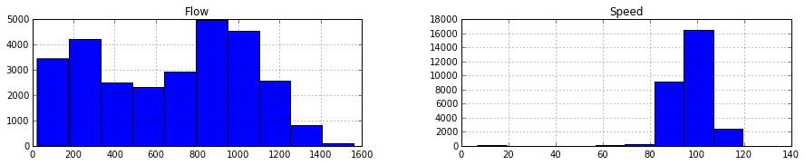

```python
_ = traffic_data[["Flow","Speed"]].hist(figsize=(15,2.5))
```

```python
days = ["Monday", "Tuesday", "Wednesday", "Thursday", "Friday", "Saturday", "Sunday"]
p_values = pd.DataFrame(index=days, columns=days)

for i_idx, i_day in enumerate(days):
    for j_idx, j_day in enumerate(days):
        days1 = traffic_data["Flow"][traffic_data.index.dayofweek == i_idx]
        days2 = traffic_data["Flow"][traffic_data.index.dayofweek == j_idx]
        p = stats.mannwhitneyu(days1, days2)[1]*2
        p_values.loc[i_day][j_day] = round(p, 4)

p_values
```

|  | Monday | Tuesday | Wednesday | Thursday | Friday | Saturday | Sunday |
| --- | --- | --- | --- | --- | --- | --- | --- |
| Monday | 1 | 0 | 0 | 0 | 0.0001 | 0 | 0 |
| Tuesday | 0 | 1 | 0.4881 | 0.2491 | 0 | 0 | 0 |
| Wednesday | 0 | 0.4881 | 1 | 0.0639 | 0 | 0 | 0 |
| Thursday | 0 | 0.2491 | 0.0639 | 1 | 0 | 0 | 0 |
| Friday | 0.0001 | 0 | 0 | 0 | 1 | 0 | 0 |
| Saturday | 0 | 0 | 0 | 0 | 0 | 1 | 0 |
| Sunday | 0 | 0 | 0 | 0 | 0 | 0 | 1 |

All the values in the table smaller than p-critical (0.05), means that we can reject our null hypothesis, therefore we can conclude that this two samples (days) are statistically different. Interesting results can be seen in the table above. We can see that for almost all combinations between different days of the week, there is a significant difference. But there are also some combinations, where p value is larger than p-critical (0.05), and therefore we cannot reject our null hypothesis. This combinations are Wednesday-Tuesday, Thursday-Tuesday and Wednesday-Thursday. It looks like the traffic between this days is very similar, which can also be observed from the figure at the beginning of this blog, showing one week of traffic data. Even though this three days in the middle of the week are very similar, we can still conclude that most of the days are significantly different, therefore it would make sense to include also day of the week as a feature in to our model.

### Adding DateTime Features

According to the results from statistical tests, we have decided to add three extra features, that we can extract from DateTime data. This features are:

- hour of day *[0 -23]*
- day of week *[0 - 6]*
- weekday/weekend *[0 - 1]*

```python
traffic_data["Hour"] = traffic_data.index.hour # Could try cyclic hours
traffic_data["DayOfWeek"] = traffic_data.index.dayofweek
traffic_data["Weekday"] = traffic_data.DayOfWeek.apply(lambda x: 1 if x < 5 else 0)

traffic_data.head()
```

|  | SensorID | Flow | Gap | Occupancy | Speed | TrafficStatus | Target | Hour | DayOfWeek | Weekday |
| --- | --- | --- | --- | --- | --- | --- | --- | --- | --- | --- |
| 2014-01-01 01:00:00 | 0178-11 | 192 | 18.5 | 14 | 105 | 1 | 120 | 1 | 2 | 1 |
| 2014-01-01 01:05:00 | 0178-11 | 156 | 21.6 | 11 | 100 | 1 | 84 | 1 | 2 | 1 |
| 2014-01-01 01:10:00 | 0178-11 | 228 | 16.3 | 16 | 112 | 1 | 192 | 1 | 2 | 1 |
| 2014-01-01 01:15:00 | 0178-11 | 300 | 11.7 | 23 | 99 | 1 | 108 | 1 | 2 | 1 |
| 2014-01-01 01:20:00 | 0178-11 | 144 | 22.2 | 10 | 108 | 1 | 156 | 1 | 2 | 1 |

### Feature Selection

One of the assumptions of linear regression model is, that input features are statistically independent (uncorrelated) with each other. Some methods (e.g. generalized least squares) are capable of handling correlated errors, although they typically require significantly more data unless some sort of regularization is used to bias the model towards assuming uncorrelated errors. In order to find if we have any strongly correlated features, we will visualize correlations between features and calculate them.

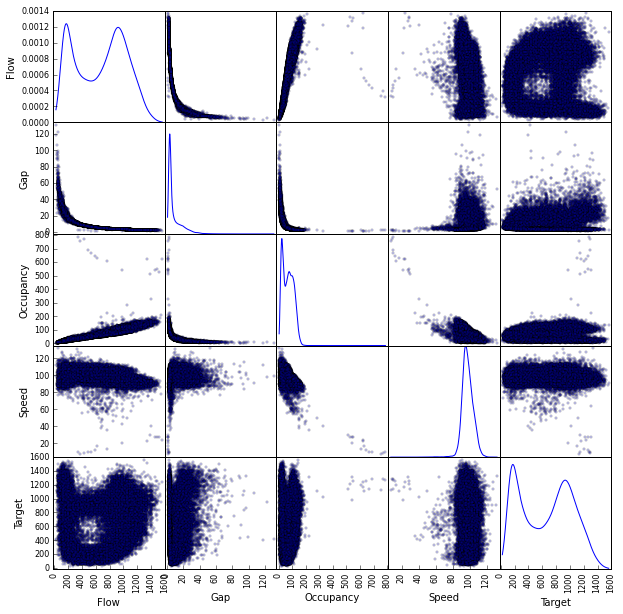

```python
from pandas.tools.plotting import scatter_matrix
_ = scatter_matrix(traffic_data[["Flow","Gap","Occupancy","Speed","Target"]], alpha=0.2, figsize=(10,10), diagonal='kde')
```

```python
traffic_data.corr()
```

|  | Flow | Gap | Occupancy | Speed | TrafficStatus | Target | Hour | DayOfWeek | Weekday |
| --- | --- | --- | --- | --- | --- | --- | --- | --- | --- |
| Flow | 1.000000 | -0.783849 | 0.908716 | -0.329379 | 0.948340 | 0.086402 | 0.388996 | -0.091594 | 0.121638 |
| Gap | -0.783849 | 1.000000 | -0.695047 | 0.173385 | -0.684661 | 0.133440 | -0.522736 | -0.008189 | 0.001963 |
| Occupancy | 0.908716 | -0.695047 | 1.000000 | -0.549084 | 0.894038 | 0.150159 | 0.292287 | -0.230205 | 0.245014 |
| Speed | -0.329379 | 0.173385 | -0.549084 | 1.000000 | -0.375430 | -0.096833 | -0.063581 | 0.337346 | -0.368982 |
| TrafficStatus | 0.948340 | -0.684661 | 0.894038 | -0.375430 | 1.000000 | 0.143786 | 0.311193 | -0.114976 | 0.138730 |
| Target | 0.086402 | 0.133440 | 0.150159 | -0.096833 | 0.143786 | 1.000000 | -0.650360 | -0.062400 | 0.102102 |
| Hour | 0.388996 | -0.522736 | 0.292287 | -0.063581 | 0.311193 | -0.650360 | 1.000000 | -0.041047 | 0.042684 |
| DayOfWeek | -0.091594 | -0.008189 | -0.230205 | 0.337346 | -0.114976 | -0.062400 | -0.041047 | 1.000000 | -0.794089 |
| Weekday | 0.121638 | 0.001963 | 0.245014 | -0.368982 | 0.138730 | 0.102102 | 0.042684 | -0.794089 | 1.000000 |

### Creating LinearRegressionModel

For this research, linear regression model was wrapped into a python object. When creating an instance of this object, one can define a target variable, and parameters to compute features from, given the dataframe. There is also a third optional parameter, which can transform categorical features in binary features. Object has two methods; train - where we define on which data model should be trained, and predict - where data from which predictions should be computed are passed.

Linear regression algorithm is used in this research works by solving Ordinary Least Square - OLS equation (with the help of scipy.linalg.lstsq() method). Ordinary Least Square (OLS) is the simplest and thus most common estimator. It is conceptually simple and computationally straightforward. OLS estimates are commonly used to analyze both experimental and observational data. This method seeks to minimize the sum of squared residuals that can be compactly written as \begin{equation*} \|A\mathbf{x}-\mathbf{b}\|^2 \end{equation*} This leads to a closed-form expression for the estimated value of the unknown parameter β:

\begin{equation*} \hat{\boldsymbol\beta} = (\mathbf{X}^{\rm T}\mathbf{X})^{-1} \mathbf{X}^{\rm T}\mathbf{y} \end{equation*}

This is also known as "normal equation". There several options how to solve this equations:

- dedicated regularized least-squares routine,
- conjugate gradient solver,
- Cholesky decomposition of dot(X.T, X),
- using Singular Value Decomposition of X to compute parameters,

```python
class LinearRegressionModel:
   weights = []

   def __init__(self, features, target, dummies = None):
        self.feature_space = features
        self.target_attribute = target
        self.dummies = dummies
        LinearRegressionModel.weights = np.ones(len(features))

   def train(self, dataframe):
        values = dataframe[self.target_attribute]
        features = dataframe[self.feature_space]

        if (self.dummies != None):
            features = self.parse_dummies(features, dataframe)

        features["ones"] = np.ones(dataframe.shape[0])
        features_array = np.array(features)
        values_array = np.array(values).flatten()

        Model.weights = linalg.lstsq(features_array, values_array)[0]

   def predict(self, dataframe):
        features = dataframe[self.feature_space]

        if (self.dummies != None):
            features = self.parse_dummies(features, dataframe)

        features["ones"] = np.ones(dataframe.shape[0])
        features_array = np.array(features)

        predictions = np.dot(features_array, Model.weights)
        return predictions

   def parse_dummies(self, features, dataframe):
        for dummie in self.dummies:
            features = features.join(pd.get_dummies(dataframe[dummie], prefix=dummie))
            del features[dummie]
        return features
```

We will create several different instances of the model described in previous chapter. This instances will contain different features, from which the model will learn, and predict. We will create these four models:

- **Model 1: "Traffic features"** - is using only traffic features from the sensors
- **Model 2: "All features"** - is using traffic features, and additional date time features extracted in previous chapter
- **Model 3: "Reduced features"** - is using the same features as Model 2, minus features that were found heavily correlated in previous chapter
- **Model 4: "Dummy features"** - is using the same features as Model 2, but with binary (dummy) features

```python
# Model 1: "Traffic features"
feature_space = ["Flow","Gap","Occupancy","Speed","TrafficStatus"]
Model1 = LinearRegressionModel(feature_space, ["Target"])

# Model 2: "All features"
feature_space = ["Flow","Gap","Occupancy","Speed","TrafficStatus","Hour","DayOfWeek","Weekday"]
Model2 = LinearRegressionModel(feature_space, ["Target"])

# Model 3: "Reduced features"
feature_space = ["Flow","Speed","Hour","DayOfWeek","Weekday"]
Model3 = LinearRegressionModel(feature_space, ["Target"])

# Model 4: "Dummy features"
feature_space = ["Flow","Gap","Occupancy","Speed","TrafficStatus","Hour","DayOfWeek","Weekday"]
dummy_features = ["Hour", "DayOfWeek"]
Model4 = LinearRegressionModel(feature_space, ["Target"], dummy_features)
```

## Evaluation

In order to evaluate models defined above, we will use Coefficient of determination (R squared). This is a number that indicates how well data fit a statistical model. Our dataset is also splited into 2 subset: training model and testing model. On the first subset, we will train the models and on the other, models will be tested. If we train and test our model on the same dataset, we risk the problem of over fitting (also this can be considered as cheating).

```python
def compute_r_squared(data, predictions):
    SST = ((data-np.mean(data))**2).sum()
    SSReg = ((predictions-np.mean(data))**2).sum()
    r_squared = SSReg / SST

    return r_squared
```

```python
# Split original dataset to training and testing subset
splitting_point = int(0.5 * traffic_data.shape[0])
training_traffic_data = traffic_data[:splitting_point]
testing_traffic_data = traffic_data[splitting_point:]

# This variable will contain R2 measure from all different models
R2_results = pd.DataFrame({'R2_score': pd.Series(index=["Model1","Model2","Model3","Model4"])})
```

### Model 1: "Traffic features"

```
R2_score    0.241693
Name: Model1, dtype: float64
```

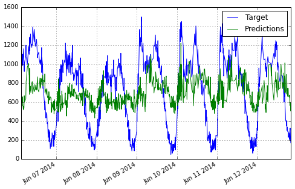

```python
# Make predictions
Model1.train(training_traffic_data)
testing_traffic_data["Predictions"] = Model1.predict(testing_traffic_data)

# Evaluate prediction
R2_results.loc["Model1"] = compute_r_squared(testing_traffic_data["Target"], testing_traffic_data["Predictions"])
print R2_results.loc["Model1"]

# Plot results
plotting_data = testing_traffic_data['2014-06-06 03:00:00':'2014-06-13 01:00:00'][['Target','Predictions']]
_ = plotting_data.plot(figsize=(8,5))
```

From the graph above we can see that our predictions thit not fit very well to the target data. R2 value is 0.24.

### Model 2: "All features"

```
R2_score    0.531553
Name: Model2, dtype: float64
```

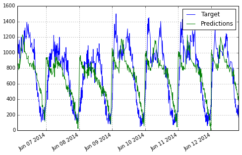

```python
# Train model with training set and predict with testing set
Model2.train(training_traffic_data)
testing_traffic_data["Predictions"] = Model2.predict(testing_traffic_data)

# Evaluate prediction
R2_results.loc["Model2"] = compute_r_squared(testing_traffic_data["Target"], testing_traffic_data["Predictions"])
print R2_results.loc["Model2"]

# Plot results
plotting_data = testing_traffic_data['2014-06-06 03:00:00':'2014-06-13 01:00:00'][['Target','Predictions']]
_ = plotting_data.plot(figsize=(8,5))
```

From this graph we can see that additional features, extracted from datetime, signifficantlly improve prediction accuracy. R2 value is now 0.53.

### Model 3: "Reduced features"

```
R2_score    0.526483
Name: Model3, dtype: float64
```

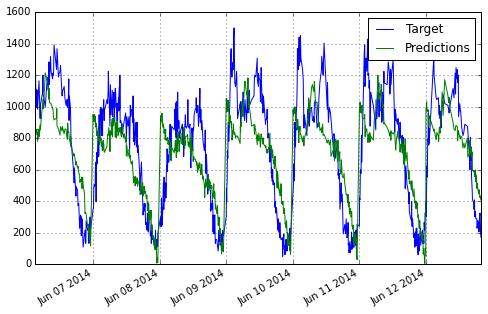

```python
# Train model with training set and predict with testing set
Model3.train(training_traffic_data)
testing_traffic_data["Predictions"] = Model3.predict(testing_traffic_data)

# Evaluate prediction
R2_results.loc["Model3"] = compute_r_squared(testing_traffic_data["Target"], testing_traffic_data["Predictions"])
print R2_results.loc["Model3"]

# Plot results
plotting_data = testing_traffic_data['2014-06-06 03:00:00':'2014-06-13 01:00:00'][['Target','Predictions']]
_ = plotting_data.plot(figsize=(8,5))
```

Model 3, contains reduced features, due to correlations that was found out during the analysis. But as we can see from the R2 value, this this not contribute to better prediction, since R2 is now lower 0.52.

### Model 4: "Dummy features"

```
R2_score    0.753404
Name: Model4, dtype: float64
```

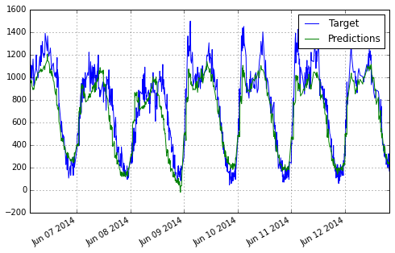

```python
# Train model with training set and predict with testing set
Model4.train(training_traffic_data)
testing_traffic_data["Predictions"] = Model4.predict(testing_traffic_data)

# Evaluate prediction
R2_results.loc["Model4"] = compute_r_squared(testing_traffic_data["Target"], testing_traffic_data["Predictions"])
print R2_results.loc["Model4"]

# Plot results
plotting_data = testing_traffic_data['2014-06-06 03:00:00':'2014-06-13 01:00:00'][['Target','Predictions']]
_ = plotting_data.plot(figsize=(8,5))
```

On this graph, we can observe our fourth developed model, which contains all the features, where datetime features were converted into binary features. As we can see, this has signifficantlly improve model prediction, with R2 value 0.75.

## Conclusion and Future work

In this research, we have shown the whole process of developing prediction model for one particular sensor, that is able to predict traffic flow 5 hours into the future. First, data were described in detail. Dataset was then cleaned and reduced. Statistical tests were then performed to get a better understanding of data. Additional features were extracted from timestamp of each record. Linear regression model (OCL) was then described, and 4 different models were developed. Each containing different features set. This models were then tested and evaluated on testing set. The result can be seen on bellow figure, where we can see that our Model4 gave the best results. From this we can conclude, that additional datetime features has a significant impact on prediction accuracy. If this features are also parsed into binary features, this results to even better accuracy.

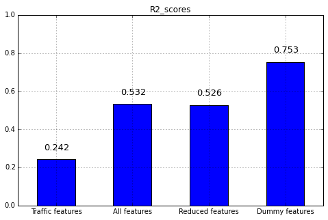

```python
fig = R2_results.plot(kind="Bar", ylim=(0,1), legend=False, title="R2_scores", figsize=(8,5))
fig.set_xticklabels(["Traffic features","All features","Reduced features", "Dummy features"], rotation=0)
for i, label in enumerate(list(R2_results.index)):
    score = R2_results.ix[label]['R2_score']
    fig.annotate(str(np.round(score, 3)), (i - 0.15, score + 0.05), fontsize=13)
```

As we have already mentioned, this research has shown modelling of traffic only for one specific sensor. Even if the method is relatively simple, and computationally non demanding, we can expect some problems if we would have to model thousands of different sensors. Not to even mention, that we would need also different models for different predictions horizons, or different parameters (speed, occupancy, ...). This is the case where MapReduce could significantly improve this process.

Finally, we can conclude that we have shown good prediction results, and that linear regression with additional datetime features can be used for predicting traffic flow. Work such as this one, can lead to development of advanced applications that aims to provide innovative services related to traffic management and transportation, that result to reducing traffic congestions, emissions, energy consumptions, delays and improved safety.